# Data Visualisation using RShiny

**Tanzania**, August, 2019

## Background

### **What is RShiny?**

- “Shiny is an R package that makes it easy to build interactive web applications (apps) straight from R.”

### **Why build interactive graphics?**

- To explore and discover data
- Communicate your results to colleagues, stakeholders, managers
- Allow others to explore their own hypotheses

## Course Overview

### **Day 1:**

- Getting to know your data
- Data subsetting, summarising
- Building exploratory plots
- Building an interactive plot in RShiny

### **Day 2:**

- Introduction to leaflet
- Building a leaflet map in R
- Building an interactive map in RShiny

### **Day 3:**

- Review
- Build your own apps!

## Daily Schedule

### **Morning Session**

- Part 1 8:30-10:30
- Break 10:30-11
- Part 2 11-1

### **Lunch: 1-2pm**

### **Afternoon Session**

- Part 3 2-4

## Getting Help

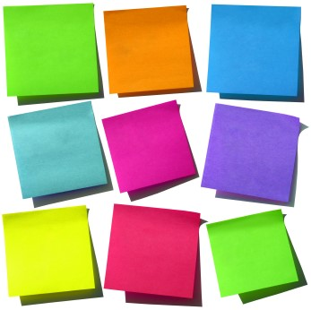

- **Yellow:** task completed
- **Pink:** for help

## Deadly virus spreads through Tanzania!

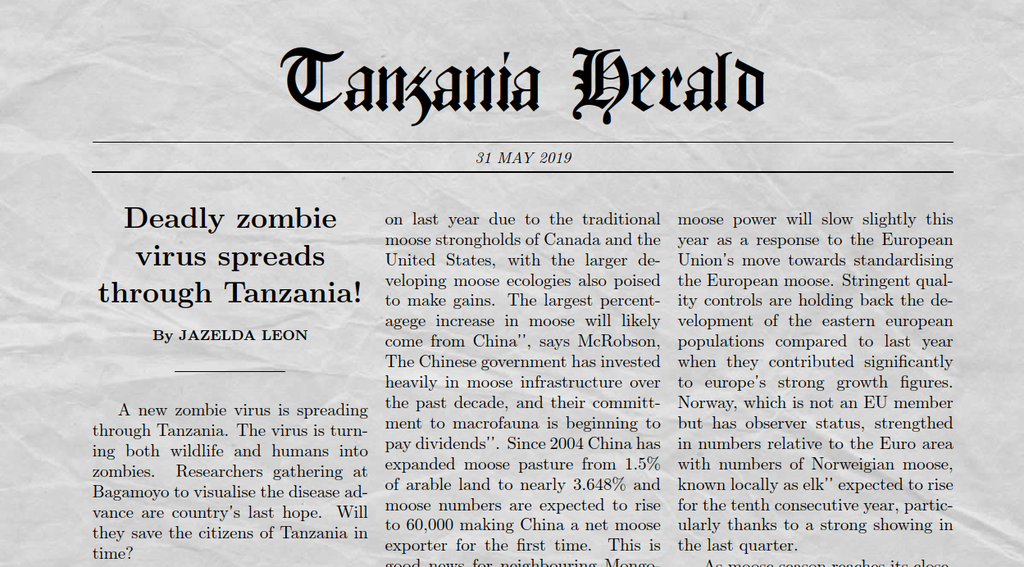

**Your mission** Visualise the disease advance and save the wildlife and citizens of Tanzania!!

## Day 1

- **1.1 Getting to know your data**
- 1.2 Data subsetting and summarising
- 1.3 Building exploratory plots
- 1.4 Building an interactive plot in RShiny

## Getting to know the data

Open the file **Day1_intro.R** in Day1 > scripts in RStudio Step 1: Set the working directory

```r
# Open the file
# Set your working directory by clicking on the top menu:
# Session > Set Working Directory > To Source File Location
```

Step 2: Load packages

```r
library("dplyr")
```

Step 3: Read in the data

```r
raw_data <- read.csv("data/raw_data.csv")
```

## Getting to know the data

We have several tools to get to know our data

- `View()`: allows us to view the dataframe as a spreadsheet.
- `nrow()`: tells us the number of rows in our data frame.
- `names()`: give us the names of the columns in our data frame.
- `dim()`: tells us the dimensions of our data frame.
- `summary()`: give us summary statistics (counts, min, median, mean, max).
- `head()`: gives us the first 6 elements of the data.
- `tail()`: gives us the last 6 elements of the data.
- `str()`: tells us the variable type (e.g. Factor, num (number), int (integer)).
- `unique()`: tells us the unique elements of a variable.
- `table()`: gives us count number for the columns specified.
- `?` and `??` accesses the help file for a function.

## Your Turn

- Navigate to Day 1/worksheets, and open **1.0_worksheet.html**
- All the activities we’ll guide you to are in this file.
- The contents table is interactive - you can click to move to the activity.

Complete section 1.1a of the worksheet

## Summary - section 1.1a

**How many entries does the data frame have?**

```r
nrow(raw_data)
```

```
## [1] 1599
```

## Summary - section 1.1a

**What are the names of the first 3 columns?**

```r
names(raw_data)
```

```
## [1] "month"   "date"    "sex"     "species" "age"     "y"       "x"
## [8] "density" "region"
```

## Summary - section 1.1a

**What are the dimensions of our data?**

```r
dim(raw_data)
```

```
## [1] 1599    9
```

## Summary - section 1.1a

**What is the mean age of those infected?**

```r
summary(raw_data)
```

```
##      month           date               sex              species
##  Min.   : 1.00   Length:1599        Length:1599        Length:1599
##  1st Qu.:31.00   Class :character   Class :character   Class :character
##  Median :39.00   Mode  :character   Mode  :character   Mode  :character
##  Mean   :38.91
##  3rd Qu.:48.00
##  Max.   :60.00
##       age               y                 x            density
##  Min.   : 0.000   Min.   :-11.545   Min.   :29.63   Min.   :    0.442
##  1st Qu.: 2.000   1st Qu.: -7.665   1st Qu.:32.93   1st Qu.:   17.930
##  Median : 5.000   Median : -5.162   Median :34.87   Median :   75.399
##  Mean   : 7.997   Mean   : -5.626   Mean   :35.03   Mean   :  666.388
##  3rd Qu.: 7.000   3rd Qu.: -3.377   3rd Qu.:37.31   3rd Qu.:  191.919
##  Max.   :80.000   Max.   : -1.000   Max.   :40.23   Max.   :11597.035
##     region
##  Length:1599
##  Class :character
##  Mode  :character
##
##
##
```

## Summary - section 1.1a

**In which region did the 1st case occur?**

```r
head(raw_data)
```

```
##   month       date sex species age          y        x     density
## 1     1 2010-01-11   F    lion   7 -10.118060 36.80652    1.342142
## 2     1 2010-01-21   M     dog   5  -3.913624 32.30963   67.991241
## 3     1 2010-01-26   F   human  77  -3.082483 32.42628  163.757278
## 4     1 2010-01-29   F     cat   5  -5.791679 36.39258   63.662300
## 5     1 2010-01-30   F     dog   2  -8.878675 33.47841 1147.721924
## 6     2 2010-02-12   F     cat   1  -4.955150 32.96697  235.208603
##      region
## 1    Ruvuma
## 2 Shinyanga
## 3     Geita
## 4    Dodoma
## 5     Mbeya
## 6    Tabora
```

## Summary - section 1.1a

**In which region did the last case occur?**

```r
tail(raw_data)
```

```
##      month       date sex species age         y        x     density
## 1594    60 2014-12-23   M     dog   4 -9.251128 33.63813  816.886047
## 1595    60 2014-12-24   F    lion   5 -3.847402 31.89355    4.928926
## 1596    60 2014-12-26   F    lion   2 -8.578295 38.63420    1.729679
## 1597    60 2014-12-26   M     dog   2 -6.828035 39.22131 9218.059570
## 1598    60 2014-12-28   F    lion  10 -7.718219 34.52342    4.823809
## 1599    60 2014-12-30   F    lion   3 -7.215952 33.98287    4.001404
##             region
## 1594         Mbeya
## 1595     Shinyanga
## 1596         Lindi
## 1597 Dar-es-salaam
## 1598         Mbeya
## 1599       Singida
```

## Summary - section 1.1a

**Which variables are numerical (have num written next to them)?**

```r
str(raw_data)
```

```
## 'data.frame':    1599 obs. of  9 variables:
##  $ month  : int  1 1 1 1 1 2 3 4 5 5 ...
##  $ date   : chr  "2010-01-11" "2010-01-21" "2010-01-26" "2010-01-29" ...
##  $ sex    : chr  "F" "M" "F" "F" ...
##  $ species: chr  "lion" "dog" "human" "cat" ...
##  $ age    : int  7 5 77 5 2 1 6 5 1 1 ...
##  $ y      : num  -10.12 -3.91 -3.08 -5.79 -8.88 ...
##  $ x      : num  36.8 32.3 32.4 36.4 33.5 ...
##  $ density: num  1.34 67.99 163.76 63.66 1147.72 ...
##  $ region : chr  "Ruvuma" "Shinyanga" "Geita" "Dodoma" ...
```

## Summary - section 1.1a

**What types of species do we have in our dataset?**

```r
unique(raw_data$species)
```

```
## [1] "lion"   "dog"    "human"  "cat"    "jackal"
```

## Summary - section 1.1a

**Which species has the most cases?**

```r
table(raw_data$species)
```

```
##
##    cat    dog  human jackal   lion
##    319    730    163    224    163
```

## Summary - section 1.1a

**What is the first argument for the function `names()`?**

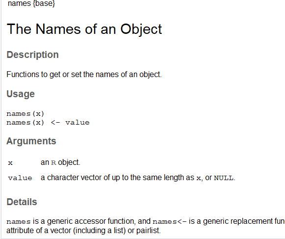

## Day 1

- 1.1 Getting to know your data
- **1.2 Data subsetting and summarising**
- 1.3 Building exploratory plots
- 1.4 Building an interactive plot in RShiny

## Data subsetting and summarising

To understand the outbreak we may want to look more closely at a particular **region**, **time**, or **variable**.

The `dplyr` package allows us to filter and select different elements using **verbs**:

- `select()` subsets columns based on their names.
- `filter()` subsets rows based on their values.
- `summarise()` calculates summary statistics.
- `group_by()` groups variables for summarising.
- `mutate()` adds new columns that are functions of existing variables.

Similar to regular R you can use the `<-` or `=` to store the object

## Subsetting columns using `select()`

`select()` subsets columns based on their names.

**E.g. Subset for the species column:**

```r
species_df1 <-  select(raw_data, species)
head(species_df1, 3)
```

```
##   species
## 1    lion
## 2     dog
## 3   human
```

**E.g. Subset for the species, region and sex columns:**

```r
species_df3 <- select(raw_data, species, region, sex)
head(species_df3, 3)
```

```
##   species    region sex
## 1    lion    Ruvuma   F
## 2     dog Shinyanga   M
## 3   human     Geita   F
```

## Subsetting rows using `filter()`

`filter()` subsets rows based on their values.

To select the observations you want it is useful to know some comparison operators:

- `>` **greater than**
- `>=` **greater than or equal to**
- `!=` **not equal**
- `==` **equal**
- `&` **and**
- `|` **or**
- `!` **not**
- `%in% c(....)` **one in** a list of elements

## Subsetting rows using `filter()`

**E.g. Filter by value that is equal to:**

```r
filter_1 <- filter(raw_data, region == "Pwani")
head(filter_1, 3)
```

```
##   month       date sex species age         y        x   density region
## 1    11 2010-11-13   F    lion   9 -6.128340 38.75910 20.542925  Pwani
## 2    15 2011-03-11   M  jackal   8 -7.101674 38.50586  9.562180  Pwani
## 3    24 2011-12-01   M  jackal   3 -8.142100 38.27868  2.700557  Pwani
```

**E.g. Filter by value that is less than:**

```r
filter_2 <- filter(raw_data, month < 40)
head(filter_2, 3)
```

```
##   month       date sex species age          y        x    density
## 1     1 2010-01-11   F    lion   7 -10.118060 36.80652   1.342142
## 2     1 2010-01-21   M     dog   5  -3.913624 32.30963  67.991241
## 3     1 2010-01-26   F   human  77  -3.082483 32.42628 163.757278
##      region
## 1    Ruvuma
## 2 Shinyanga
## 3     Geita
```

## Subsetting rows using `filter()`

**E.g. Filter by value that is not equal to:**

```r
filter_3 <- filter(raw_data, species != "cat" & species != "dog")
head(filter_3, 3)
```

```
##   month       date sex species age          y        x    density region
## 1     1 2010-01-11   F    lion   7 -10.118060 36.80652   1.342142 Ruvuma
## 2     1 2010-01-26   F   human  77  -3.082483 32.42628 163.757278  Geita
## 3     5 2010-05-01   F  jackal   1  -9.668913 37.96974  19.467535  Lindi
```

**E.g. Filter by multiple values:**

```r
filter_4 <- filter(raw_data, species %in% c("jackal", "lion"))
head(filter_4, 3)
```

```
##   month       date sex species age          y        x   density region
## 1     1 2010-01-11   F    lion   7 -10.118060 36.80652  1.342142 Ruvuma
## 2     5 2010-05-01   F  jackal   1  -9.668913 37.96974 19.467535  Lindi
## 3     9 2010-09-24   F  jackal   4  -9.743576 37.26657  1.242519  Lindi
```

## Ifelse statements

Operators naturally pair well with ifelse statements.

```r
ifelse("dog" %in% c("dog", "lion", "jackal"), "Hi", 2+2)
```

```
## [1] "Hi"
```

```r
ifelse("cat" %in% c("dog", "lion", "jackal"), "Hi", 2+2)
```

```
## [1] 4
```

## Your Turn

Complete section 1.2a of the worksheet

## Summary - section 1.2a

**What do each of these lines of code subset the data for?**

```r
select(raw_data, x, y, age)
```

```r
filter(raw_data, region %in% c("Mara", "Pwani", "Dar-es-salaam"))
```

```r
filter(raw_data, age >= 30)
```

## Summary - section 1.2b

**What do each of these lines of code subset the data for?**

```r
select(raw_data, x, y, age)
```

```
##          x          y age
## 1 36.80652 -10.118060   7
## 2 32.30963  -3.913624   5
## 3 32.42628  -3.082483  77
## 4 36.39258  -5.791679   5
## 5 33.47841  -8.878675   2
## 6 32.96697  -4.955150   1
```

## Summary - section 1.2b

**What do each of these lines of code subset the data for?**

```r
filter(raw_data, region %in% c("Mara", "Pwani", "Dar-es-salaam"))
```

```
##   month       date sex species age         y        x     density
## 1     5 2010-05-07   M     dog   1 -1.371540 33.84519   223.42017
## 2     8 2010-08-09   F     dog   4 -1.964125 33.89336   118.17297
## 3    10 2010-10-23   M     dog   2 -6.749405 39.09952   577.96545
## 4    11 2010-11-13   F    lion   9 -6.128340 38.75910    20.54292
## 5    12 2010-12-25   F     dog   6 -6.841905 39.25924 11262.21484
## 6    14 2011-02-17   F   human  15 -6.916072 39.38472   495.19009
##          region
## 1          Mara
## 2          Mara
## 3 Dar-es-salaam
## 4         Pwani
## 5 Dar-es-salaam
## 6 Dar-es-salaam
```

## Summary - section 1.2b

**What do each of these lines of code subset the data for?**

```r
filter(raw_data, age >= 30)
```

```
##   month       date sex species age         y        x     density
## 1     1 2010-01-26   F   human  77 -3.082483 32.42628  163.757278
## 2     8 2010-08-23   M   human  57 -4.217682 34.97162   63.684662
## 3    11 2010-11-09   F   human  37 -3.660830 33.38180 1029.822632
## 4    11 2010-11-22   F   human  54 -4.543316 30.38492   95.110123
## 5    15 2011-03-31   F   human  57 -2.538718 33.14267  281.482971
## 6    18 2011-06-11   M   human  40 -8.089948 31.14642    8.223545
##      region
## 1     Geita
## 2   Manyara
## 3 Shinyanga
## 4    Kigoma
## 5    Mwanza
## 6     Rukwa
```

## Calculate summary statistics using `summarise()`

`summarise()` uses existing R functions to calculate summary statistics.

**E.g. Calculate the mean age:**

```r
summarise(raw_data, mean_age = mean(age))
```

```
##   mean_age
## 1 7.996873
```

**E.g. Calculate the total number of cases:**

```r
summarise(raw_data, total_cases = n())
```

```
##   total_cases
## 1        1599
```

## Group variables before summarising

`group_by()` can be used to group variables before summarising.

**E.g. Calculate the mean age by species:**

```r
grouped_df <- group_by(raw_data, species)
summarise(grouped_df, mean_age = mean(age))
```

```
## # A tibble: 5 x 2
##   species mean_age
##   <chr>      <dbl>
## 1 cat         4.04
## 2 dog         3.95
## 3 human      39.9
## 4 jackal      3.99
## 5 lion        7.51
```

## Your Turn

Complete section 1.2b of the worksheet

## Summary - section 1.2b

**What do each of these lines of code summarise?**

```r
summarise(raw_data, n_males = length(which(sex=="M")))
```

```r
summarise(raw_data, total_age = sum(age))
```

## Summary - section 1.2b

**What do each of these lines of code summarise?**

```r
summarise(raw_data, n_males = length(which(sex=="M")))
```

```
##   n_males
## 1     793
```

```r
summarise(raw_data, total_age = sum(age))
```

```
##   total_age
## 1     12787
```

## Summary - section 1.2b

**How are these two tables different?**

```r
df_1 <- group_by(raw_data, sex)
summarise(df_1,
          n_records = length(sex),
          mean_age = mean(age))
```

```r
df_2 <- group_by(raw_data, region, sex)
summarise(df_2,
          n_records = length(sex),
          mean_age = mean(age))
```

## Summary - section 1.2b

**How are these two tables different?**

```r
df_1 <- group_by(raw_data, sex)
summarise(df_1, n_records = length(sex), mean_age = mean(age))
```

```
## # A tibble: 2 x 3
##   sex   n_records mean_age
##   <chr>     <int>    <dbl>
## 1 F           806     7.90
## 2 M           793     8.10
```

```r
df_2 <- group_by(raw_data, region, sex)
summarise(df_2, n_records = length(sex), mean_age = mean(age))
```

```
## # A tibble: 5 x 4
## # Groups:   region [3]
##   region        sex   n_records mean_age
##   <chr>         <chr>     <int>    <dbl>
## 1 Arusha        F            36    11.7
## 2 Arusha        M            27     9.78
## 3 Dar-es-salaam F            35     6.54
## 4 Dar-es-salaam M            36    10.2
## 5 Dodoma        F            41    11.0
```

## Add new columns using `mutate()`

`mutate()` adds new columns that are functions of existing variables

**E.g. Add a new column stating human or animal:**

```r
head(mutate(raw_data, animal_type = ifelse(species == "human", "human", "animal")))
```

```
##   month       date sex species age          y        x     density
## 1     1 2010-01-11   F    lion   7 -10.118060 36.80652    1.342142
## 2     1 2010-01-21   M     dog   5  -3.913624 32.30963   67.991241
## 3     1 2010-01-26   F   human  77  -3.082483 32.42628  163.757278
## 4     1 2010-01-29   F     cat   5  -5.791679 36.39258   63.662300
## 5     1 2010-01-30   F     dog   2  -8.878675 33.47841 1147.721924
## 6     2 2010-02-12   F     cat   1  -4.955150 32.96697  235.208603
##      region animal_type
## 1    Ruvuma      animal
## 2 Shinyanga      animal
## 3     Geita       human
## 4    Dodoma      animal
## 5     Mbeya      animal
## 6    Tabora      animal
```

## Combining multiple operations

We can carry out multiple operations, using the stored object from the previous operation…

```r
pwani_df <- filter(raw_data, region == "Pwani")

pwani_non_human <- filter(pwani_df, species != "human")

pwani_non_human <- mutate(pwani_non_human,
                          "animal_type" = ifelse(species  %in% c("dog", "cat"), "domestic", "wild"))

pwani_grouped <- group_by(pwani_non_human, animal_type)

pwani_summarised <- summarise(pwani_grouped, n())

pwani_summarised
```

```
## # A tibble: 2 x 2
##   animal_type `n()`
##   <chr>       <int>
## 1 domestic       18
## 2 wild           11
```

## Combining multiple operations

… Or we can use the piping function `%>%` to join them together into 1 output

```r
pwani_summarised <-  raw_data %>%
  filter(region == "Pwani", species != "human") %>%
  mutate("animal_type" = ifelse(species %in% c("dog", "cat"),
                                "domestic", "wild")) %>%
  group_by(animal_type) %>%
  summarise(n())

pwani_summarised
```

```
## # A tibble: 2 x 2
##   animal_type `n()`
##   <chr>       <int>
## 1 domestic       18
## 2 wild           11
```

## Your Turn

Complete section 1.2c of the worksheet

## Summary - section 1.2c

**What do each of these lines of code add as a new column?**

```r
raw_data <- mutate(raw_data, "new_col_1" = substr(date, 1, 4))
```

```r
raw_data <- mutate(raw_data, "new_col_2" = ifelse(density >= 500,"High", "Low"))
```

## Summary - section 1.2c

**What do each of these lines of code add as a new column?**

```r
raw_data <- mutate(raw_data, "new_col_1" = substr(date, 1, 4))
```

```r
raw_data <- mutate(raw_data, "new_col_2" = ifelse(density >= 500,"High", "Low"))
```

| month | date | sex | species | age | y | x | density | region | new_col_1 | new_col_2 |
| --- | --- | --- | --- | --- | --- | --- | --- | --- | --- | --- |
| 1 | 2010-01-11 | F | lion | 7 | -10.1181 | 36.8065 | 1.3421 | Ruvuma | 2010 | Low |
| 1 | 2010-01-21 | M | dog | 5 | -3.9136 | 32.3096 | 67.9912 | Shinyanga | 2010 | Low |
| 1 | 2010-01-26 | F | human | 77 | -3.0825 | 32.4263 | 163.7573 | Geita | 2010 | Low |
| 1 | 2010-01-29 | F | cat | 5 | -5.7917 | 36.3926 | 63.6623 | Dodoma | 2010 | Low |
| 1 | 2010-01-30 | F | dog | 2 | -8.8787 | 33.4784 | 1147.7219 | Mbeya | 2010 | High |
| 2 | 2010-02-12 | F | cat | 1 | -4.9552 | 32.9670 | 235.2086 | Tabora | 2010 | Low |

## Summary - section 1.2c

**Fill in the blanks for the following lines of code in your R script**

Subset for only records with wildlife (i.e. jackal, lion)

```r
raw_data %>%
  ___(____________)
```

## Summary - section 1.2c

**Fill in the blanks for the following lines of code in your R script**

Subset for only records with wildlife (i.e. jackal, lion)

```r
raw_data %>%
  filter(species %in% c("jackal", "lion"))
```

```
##   month       date sex species age          y        x   density region
## 1     1 2010-01-11   F    lion   7 -10.118060 36.80652  1.342142 Ruvuma
## 2     5 2010-05-01   F  jackal   1  -9.668913 37.96974 19.467535  Lindi
## 3     9 2010-09-24   F  jackal   4  -9.743576 37.26657  1.242519  Lindi
## 4     9 2010-09-28   F  jackal   2  -8.548182 37.79473  1.532727  Lindi
## 5    10 2010-10-03   M  jackal   4  -1.384318 31.11269 78.028397 Kagera
## 6    10 2010-10-23   F    lion   2  -4.059771 31.46775  5.250402  Geita
```

## Summary - section 1.2c

Subset for humans, and summarise the mean age per region

```r
raw_data %>%
  ___(____________) %>%
  ___(region) %>%
  ___(mean_age = ________)
```

## Summary - section 1.2c

Subset for humans, and summarise the mean age per region

```r
raw_data %>%
  filter(species=="human") %>%
  group_by(region) %>%
  summarise(mean_age = mean(age))
```

```
## # A tibble: 28 x 2
##    region           mean_age
##    <chr>               <dbl>
##  1 Arusha               43.5
##  2 Dar-es-salaam        42.6
##  3 Dodoma               49.6
##  4 Geita                47.9
##  5 Iringa                8
##  6 Kagera               37.4
##  7 Kaskazini Unguja     74
##  8 Katavi               22
##  9 Kigoma               45.2
## 10 Kilimanjaro          39.6
## # ... with 18 more rows
```

## Day 1

- 1.1 Getting to know your data
- 1.2 Data subsetting and summarising
- **1.3 Building exploratory plots**
- 1.4 Building an interactive plot in RShiny

## Introducing ggplot

The basic structure:

ggplot() +  
geom_bar(data=raw_data, aes(x=sex))

## Introducing ggplot - plots

First we need to specify a plot

ggplot() +  
**geom_bar**(data=raw_data, aes(x=sex))

- ggplot has several plot types:
  - **geom_bar**: **barplot**
  - **geom_histogram**: **histogram**
  - **geom_point**: **scatterplot/points**
  - **geom_line**: **line plot**

## Introducing ggplot - data

Second we need to supply our data

ggplot() +  
**geom_bar**(**data=raw_data**, aes(x=sex))

The data can also be specified here:

ggplot(**data=raw_data**) +  
**geom_bar**(aes(x=sex))

## Introducing ggplot - aesthetics

Third, we specify the variables we want to plot using aesthetics, or aes().

ggplot() +  
**geom_bar**(**data=raw_data**, **aes(x=sex)**)

Different plots take different arguments in aes()

ggplot() +  
**geom_point**(**data=raw_data**), **aes(x=sex, y = age)**

## Barplot

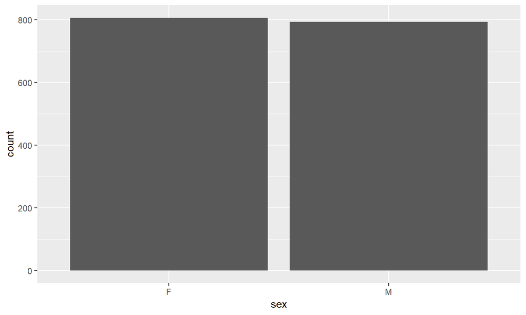

```r
ggplot() +
  geom_bar(data=raw_data, aes(x=sex))
```

## Introducing ggplot - aesthetics

Change the colour in aesthetics

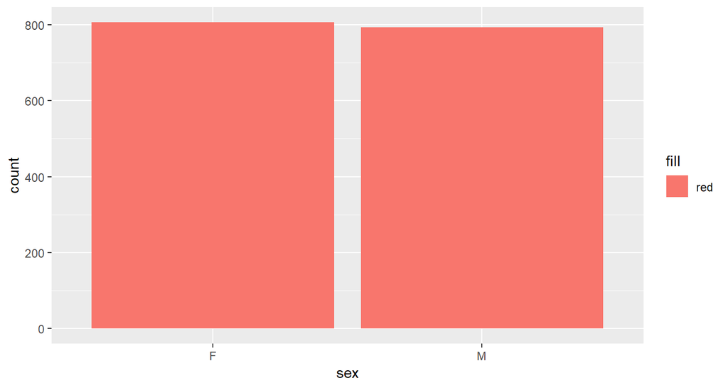

```r
ggplot() +
  geom_bar(data=raw_data, aes(x=sex, fill = "red"))
```

## Introducing ggplot - aesthetics

Change the colour in aesthetics by variable

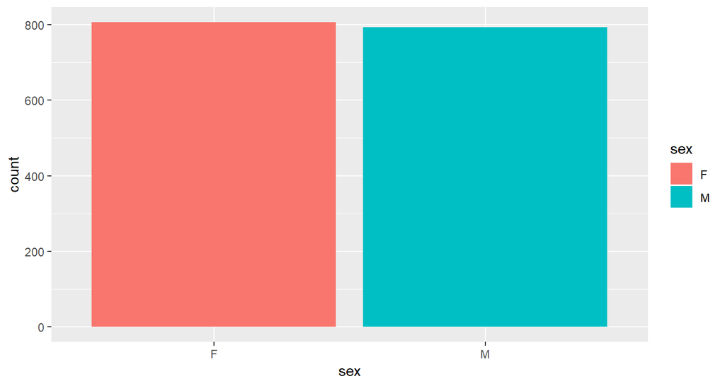

```r
ggplot() +
  geom_bar(data=raw_data, aes(x=sex, fill = sex))
```

## Introducing ggplot - additional features

Adding **labels**, **titles**, and **themes**

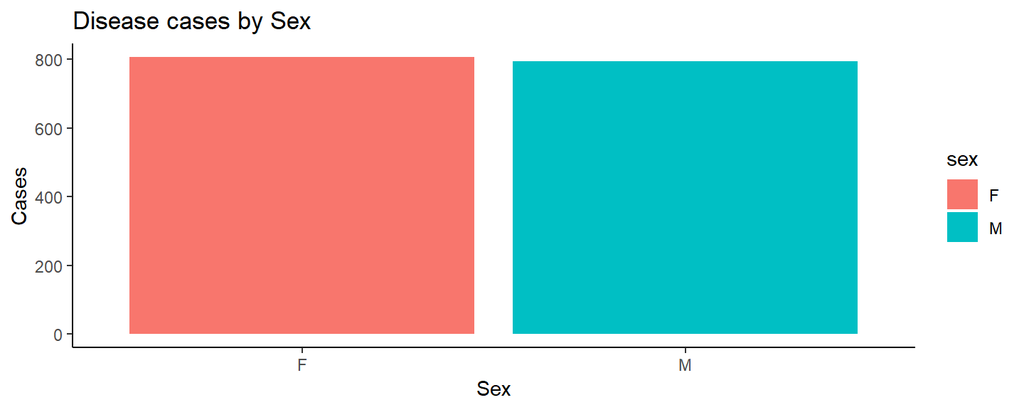

```r
ggplot() +
  geom_bar(data=raw_data, aes(x=sex, fill=sex))+
  xlab("Sex") + # Label for the X axis
  ylab("Cases") + # Label for the Y axis
  ggtitle("Disease cases by Sex") + #Title
  theme_classic() # Plot theme for background etc.
```

## Your Turn

Complete section 1.3a of the worksheet

## Summary - section 1.3a

**Create a barplot of species and colour by species.**

```r
ggplot() +
  geom_bar(data=raw_data, aes(x=________, fill = ________)) +
  theme_classic()
```

## Summary - section 1.3a

**Create a barplot of species and colour by species.**

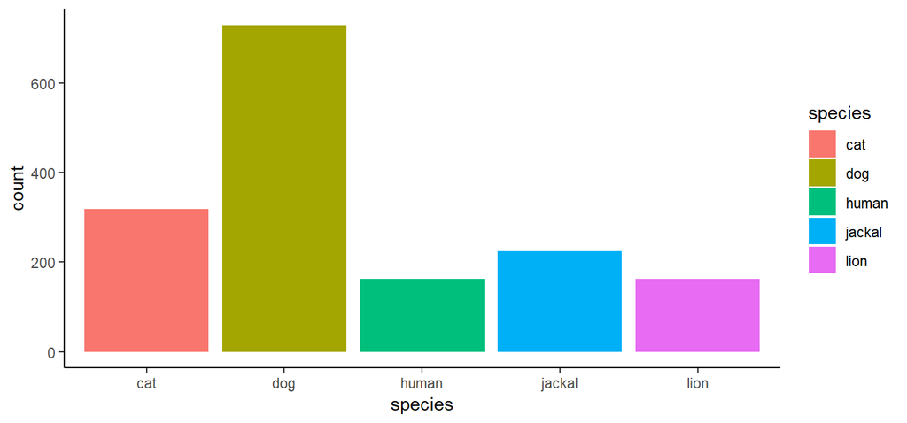

```r
ggplot() +
  geom_bar(data=raw_data, aes(x=species, fill = species)) +
  theme_classic()
```

## Summary - section 1.3a

**Add a title, x and y axis labels to the barplot of species.**

```r
ggplot() +
  geom_bar(data=raw_data, aes(x=________, fill = ________)) +
  _________ +
  _________ +
  _________ +
  theme_classic()
```

## Summary - section 1.3a

**Add a title, x and y axis labels to the barplot of species.**

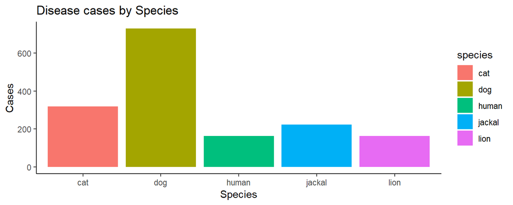

```r
ggplot() +
  geom_bar(data=raw_data, aes(x=species, fill = species))+
  xlab("Species") +
  ylab("Cases") +
  ggtitle("Disease cases by Species") +
  theme_classic()
```